# Statistical_Infer_Part2.Rmd

Joe Okelly

18/09/2024

## Instructions

1.Load the ToothGrowth data and perform some basic exploratory data analyses

2.Provide a basic summary of the data.

3.Use confidence intervals and/or hypothesis tests to compare tooth growth by supp and dose. (Only use the techniques from class, even if there’s other approaches worth considering)

## Exploratory data Analysis

First me load the packages, and dataset

```r
library(ggplot2)
library(knitr)
library(datasets)
```

Load the ToothGrowth data and perform basic Exploratory Data Analysis

```r
data(ToothGrowth)
str(ToothGrowth)
```

```
## 'data.frame':    60 obs. of  3 variables:
##  $ len : num  4.2 11.5 7.3 5.8 6.4 10 11.2 11.2 5.2 7 ...
##  $ supp: Factor w/ 2 levels "OJ","VC": 2 2 2 2 2 2 2 2 2 2 ...
##  $ dose: num  0.5 0.5 0.5 0.5 0.5 0.5 0.5 0.5 0.5 0.5 ...
```

```r
head(ToothGrowth, 4)
```

```
##    len supp dose
## 1  4.2   VC  0.5
## 2 11.5   VC  0.5
## 3  7.3   VC  0.5
## 4  5.8   VC  0.5
```

```r
tail(ToothGrowth, 4)
```

```
##     len supp dose
## 57 26.4   OJ    2
## 58 27.3   OJ    2
## 59 29.4   OJ    2
## 60 23.0   OJ    2
```

Calculate the summary of the data

```r
summary(ToothGrowth)
```

```
##       len        supp         dose
##  Min.   : 4.20   OJ:30   Min.   :0.500
##  1st Qu.:13.07   VC:30   1st Qu.:0.500
##  Median :19.25           Median :1.000
##  Mean   :18.81           Mean   :1.167
##  3rd Qu.:25.27           3rd Qu.:2.000
##  Max.   :33.90           Max.   :2.000
```

Calculate the mean of the length

```r
suppl_mean = split(ToothGrowth$len, ToothGrowth$supp)
sapply(suppl_mean, mean)
```

```
##       OJ       VC
## 20.66333 16.96333
```

```r
suppl_mean
```

```
## $OJ
##  [1] 15.2 21.5 17.6  9.7 14.5 10.0  8.2  9.4 16.5  9.7 19.7 23.3 23.6 26.4 20.0
## [16] 25.2 25.8 21.2 14.5 27.3 25.5 26.4 22.4 24.5 24.8 30.9 26.4 27.3 29.4 23.0
##
## $VC
##  [1]  4.2 11.5  7.3  5.8  6.4 10.0 11.2 11.2  5.2  7.0 16.5 16.5 15.2 17.3 22.5
## [16] 17.3 13.6 14.5 18.8 15.5 23.6 18.5 33.9 25.5 26.4 32.5 26.7 21.5 23.3 29.5
```

## Basic Exploratory Analysis, Graph below

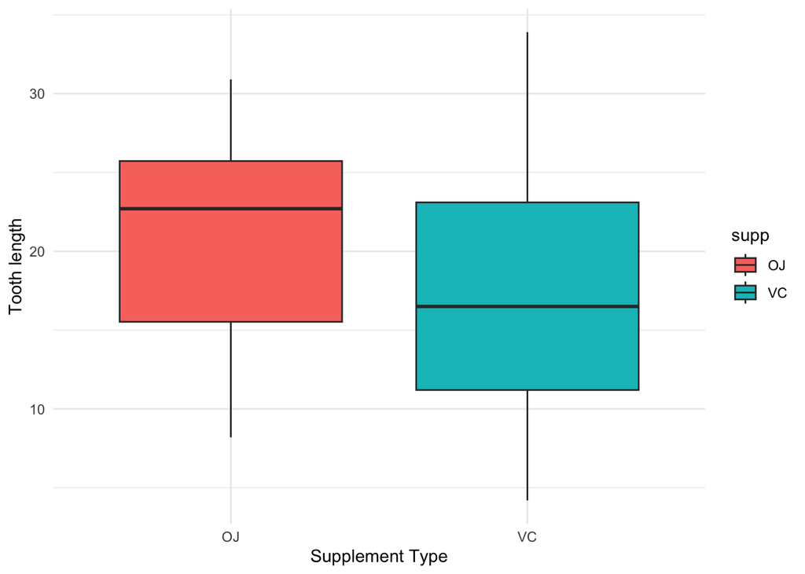

```r
ggplot(aes(x=supp, y=len), data=ToothGrowth) + geom_boxplot(aes(fill=supp))+
  xlab("Supplement Type") +ylab("Tooth length") +
  theme_minimal()
```

Above Plot gives you a basic exploratory visualization showing how tooth length varies with supplement type (supp).

```r
unique(ToothGrowth$dose)
```

```
## [1] 0.5 1.0 2.0
```

Unique dose groups are 0.5, 1.0, 2.0

Graph below, shows the relationship between Tooth Length and Dosages

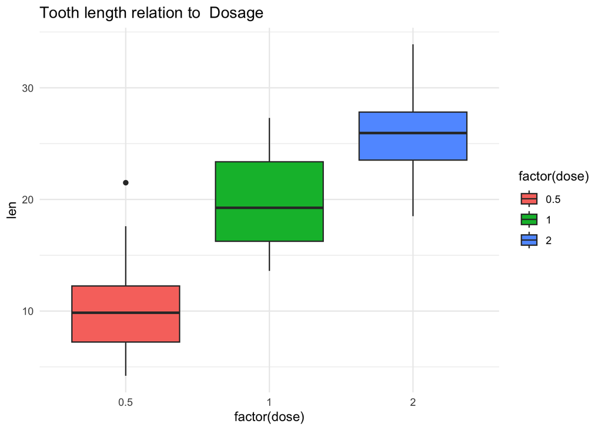

```r
 ggplot(aes(x = factor(dose), y = len), data = ToothGrowth) +
  geom_boxplot(aes(fill = factor(dose))) +
  ggtitle("Tooth length relation to  Dosage") +
  theme_minimal()
```

The above graph show the relationship between tooth length and dosage in the ToothGrowth dataset

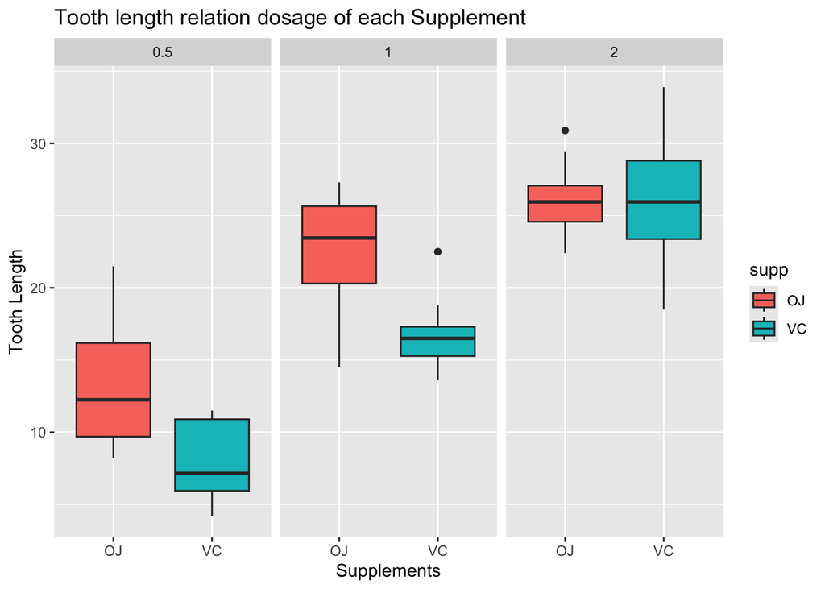

```r
ggplot(aes(x=supp, y=len), data=ToothGrowth) +
  geom_boxplot(aes(fill=supp)) + xlab("Supplements") +
  ylab("Tooth Length") + facet_grid(~ dose) +
  ggtitle("Tooth length relation dosage of each Supplement")
```

Graph above show the tooth Length relation to dosage of each supplement

Hypothesis test defined below :

𝐻0 : tooth length does not depend of different supplements 𝐻𝑎: tooth length are effected by different supplement

```r
#t.test(len ~ supp, ToothGrowth[ToothGrowth$dose == .5, ])
# For dose = 0.5
test_dose_0.5 <- t.test(len ~ supp, data = ToothGrowth[ToothGrowth$dose == 0.5, ])
print("t-test for dose 0.5:")
```

```
## [1] "t-test for dose 0.5:"
```

```r
test_dose_0.5
```

```
##
##  Welch Two Sample t-test
##
## data:  len by supp
## t = 3.1697, df = 14.969, p-value = 0.006359
## alternative hypothesis: true difference in means between group OJ and group VC is not equal to 0
## 95 percent confidence interval:
##  1.719057 8.780943
## sample estimates:
## mean in group OJ mean in group VC
##            13.23             7.98
```

```r
#t.test(len ~ supp, ToothGrowth[ToothGrowth$dose == 1, ])
# For dose = 1
test_dose_1 <- t.test(len ~ supp, data = ToothGrowth[ToothGrowth$dose == 1, ])
print("t-test for dose 1:")
```

```
## [1] "t-test for dose 1:"
```

```r
test_dose_1
```

```
##
##  Welch Two Sample t-test
##
## data:  len by supp
## t = 4.0328, df = 15.358, p-value = 0.001038
## alternative hypothesis: true difference in means between group OJ and group VC is not equal to 0
## 95 percent confidence interval:
##  2.802148 9.057852
## sample estimates:
## mean in group OJ mean in group VC
##            22.70            16.77
```

```r
#t.test(len ~ supp, ToothGrowth[ToothGrowth$dose == 2, ])
# For dose = 2
test_dose_2 <- t.test(len ~ supp, data = ToothGrowth[ToothGrowth$dose == 2, ])
print("t-test for dose 2:")
```

```
## [1] "t-test for dose 2:"
```

```r
test_dose_2
```

```
##
##  Welch Two Sample t-test
##
## data:  len by supp
## t = -0.046136, df = 14.04, p-value = 0.9639
## alternative hypothesis: true difference in means between group OJ and group VC is not equal to 0
## 95 percent confidence interval:
##  -3.79807  3.63807
## sample estimates:
## mean in group OJ mean in group VC
##            26.06            26.14
```

### Interpretation of Results:

For each t-test, you’ll get:

t-value: The test statistic. p-value: Determines whether to reject the null hypothesis. If the p-value is less than your significance level (e.g., 0.05), you reject 𝐻0 and conclude that tooth length is significantly different between supplements for that dose.

Confidence Interval: The range of values that likely contains the true difference in means.

What to Look For: Low p-values (p < 0.05): Suggest that the tooth length does depend on the supplement type. High p-values (p > 0.05): Suggest that there is no significant difference in tooth length between the supplements.